# Beach Tan Analysis: Examining How Different Client Variables Affect Retail Revenue

Sydney Harris

Masters of Science in Business Analytics, Miami University, OH 45056

harri106@miamioh.edu

October 09, 2020

# 1 Overview of the Purpose of Analysis

Beach Tan is a popular indoor tanning salon that has several locations across the US. While Beach Tan is a very popular indoor tanning destination, Beach Tan struggles with getting their clients to purchase retail. A lot of clients purchase their retail online rather than in store. Due to this, Beach Tan’s marketing team was tasked with creating more targted promotions for retail to increase retail revenue at Beach Tan locations. Currrently, the marketing team’s promotions are broad and the same for every client. The marketing team wants to know what type of clients are purchasing retail and what type of clients are not so they can better target certain clients with retail ads.

In this analysis, I attempt to gain a deeper insight into the tanning habits of Beach Tan customers by examining how a client’s age, gender, membership type, membership level, amount of sunless tans, and amount of UV tans affect Beach Tan’s retail revenue. To do so, I created a multiple linear regression model on the Beach Tan data that was pulled from BeachTan dataset. It is important to note that this data was preprocessed by Dr.Jones-Farmer. The csv for the BeachTan data and the excel file with the data dictionary are included in the github 616-Project.

## 1.2 Packages Used

First, I cleared my global environment to start this analysis fresh without any other data that I have previously used.

```r
rm(list = ls())
```

If pacman isn’t already installed, I used the following code to ask the user to install pacman.

```r
if(require(pacman)==FALSE)
  install.packages("pacman")
```

I then used the p_load function to install the required packages for this analysis.

I used the DataExplorer package to plot the amount of missingness in each variable.

I used the tidyverse, backports, dplyr, and forcats packages to recode variable levels.

I used pacman so this version of R can be accessed with the correct packages when this analysis is reproduced in the future.

```r
p_load(DataExplorer, dplyr, tidyverse, backports, forcats)
```

# 2 Description of Beach Tan Data

The Beach Tan data set has 11,041 observations which were compiled from ten different Beach Tan store locations in 2014.

The variables are as follows:

- **UIDClient**: Client Identification Number
- **UIDStoreLocation**: Store Identification Number
- **Gender**: 0 = Female, 1 = Male
- **DateJoined**: Date the client became a member of Beach Tan. If the client is a non-member, this is the date and time of their first tanning session.
- **DaysSinceJoined**: The number of days elapsed between DateJoined and 11/1/2014.
- **MembershipType**: 0 = Non Membership, 1 = Monthly Membership, 2 = Annual Membership
- **MembershipLevel**: Types of levels are based on the level of tanning equiptment. The higher the membership level, the higher the tanning equiptment level availiable to the client. Higher tanning equiptment results in faster tanning results. 0 = Non Membership, 1 = Fas, 2 = Faster, 3 = Fastest, 4 = Instant
- **Age**: Age of client in years
- **UVTans**: The number of Ultra Violet Tans a client has taken since they joined Beach Tan. UV tans include tans in UV beds or tans in stand-up booths.
- **SunlessTans**: The number of sunless tans a client has taken since they joined Beach Tan. Sunless tans are spray tans.
- **UpgradeRevenue**: Amount spent in dollars by members to tan in a higher level bed than what their regular membership includes.
- **RetailRevenue**: Amount spent in dollars on various skin care lotions and products that Beach Tan offers.

Here is a glimpse of the data to get a better look. Several variable’s data types are incorrect. I will discuss which ones I need to change in the preprocessing section of this analysis.

```r
BeachTan_original<-read.csv("BeachTan_original.csv", stringsAsFactors = TRUE)
head(BeachTan_original)
```

|  | UIDClient | UIDStoreLocation | Gender | DateJoined | DaysSinceJoined | MembershipType | MembershipLevel | Age | UVTans | SunlessTans | UpgradeRevenue | RetailRevenue |
| --- | --- | --- | --- | --- | --- | --- | --- | --- | --- | --- | --- | --- |
| 1 | 597 | 1 | 0 | 3/13/2010 | 1694 | 2 | 0 | 38 | 189 | 4 | 56 | 76.01 |
| 2 | 17873 | 1 | 0 | 10/3/2009 | 1855 | 2 | 0 | 48 | 0 | 26 | 25 | 171.32 |
| 3 | 26441 | 1 | 0 | 3/18/2007 | 2785 | 2 | 1 | 76 | 265 | 58 | 15 | 190.23 |
| 4 | 31132 | 1 | 0 | 3/18/2007 | 2785 | 2 | 0 | 40 | 327 | 18 | 0 | 399.58 |
| 5 | 31382 | 1 | 0 | 4/24/2012 | 921 | 2 | 0 | 20 | 90 | 0 | 8 | 66.99 |
| 6 | 44204 | 1 | 0 | 6/22/2007 | 2689 | 2 | 0 | 20 | 162 | 17 | 0 | 323.16 |

```r
tail(BeachTan_original)
```

|  | UIDClient | UIDStoreLocation | Gender | DateJoined | DaysSinceJoined | MembershipType | MembershipLevel | Age | UVTans | SunlessTans | UpgradeRevenue | RetailRevenue |
| --- | --- | --- | --- | --- | --- | --- | --- | --- | --- | --- | --- | --- |
| 11036 | 107082 | 10 | 1 | 5/3/2011 | 1278 | 0 | 0 | 19 | 3 | 0 | 0 | 2.69 |
| 11037 | 107115 | 10 | 0 | 4/7/2011 | 1304 | 0 | 0 | 21 | 6 | 0 | 0 | 9.99 |
| 11038 | 107118 | 10 | 0 | 4/12/2012 | 933 | 0 | 0 | 22 | 1 | 2 | 0 | 0.44 |
| 11039 | 107351 | 10 | 0 | 5/1/2010 | 1645 | 0 | 0 | 23 | 5 | 0 | 0 | 16.54 |
| 11040 | 107507 | 10 | 0 | 3/16/2013 | 595 | 0 | 0 | 41 | 4 | 1 | 0 | 8.09 |
| 11041 | 107602 | 10 | 1 | 1/11/2012 | 1025 | 0 | 0 | 25 | 5 | 0 | 0 | 2.99 |

# 3 Details On Data Preprocessing

## 3.1 Converting Variables to the Correct Data Types

Before I analyze the variables that had missing values, I need to convert the following variables to their correct data types.

Several variables have incorrect datatypes which need to be fixed. I looked at the data types to better examine which variables have incorrect datatypes.

```r
str(BeachTan_original)
```

```
## 'data.frame':    11041 obs. of  12 variables:
##  $ UIDClient       : int  597 17873 26441 31132 31382 44204 50652 81049 98231 9020 ...
##  $ UIDStoreLocation: int  1 1 1 1 1 1 1 1 1 2 ...
##  $ Gender          : Factor w/ 4 levels "","#NULL!","0",..: 3 3 3 3 3 3 3 3 3 3 ...
##  $ DateJoined      : Factor w/ 2840 levels "","1/1/2008",..: 1116 377 1171 1171 1599 2150 1918 1185 2165 2607 ...
##  $ DaysSinceJoined : int  1694 1855 2785 2785 921 2689 2351 2053 1591 1160 ...
##  $ MembershipType  : int  2 2 2 2 2 2 2 2 2 2 ...
##  $ MembershipLevel : int  0 0 1 0 0 0 0 4 0 1 ...
##  $ Age             : int  38 48 76 40 20 20 52 40 63 21 ...
##  $ UVTans          : int  189 0 265 327 90 162 2 34 11 306 ...
##  $ SunlessTans     : int  4 26 58 18 0 17 1 2 0 0 ...
##  $ UpgradeRevenue  : int  56 25 15 0 8 0 0 0 0 0 ...
##  $ RetailRevenue   : num  76 171 190 400 67 ...
```

Currently, MembershipType is an integer but it needs to be changed to a factor because it has categorical levels.

```r
BeachTan_original$MembershipType<-as.factor(BeachTan_original$MembershipType)
```

MembershipLevel is currently an integer but needs to be changed to a factor because it has categorical levels.

```r
BeachTan_original$MembershipLevel<-as.factor(BeachTan_original$MembershipLevel)
```

DateJoined is currently a factor but should be a date.

```r
BeachTan_original$DateJoined<- as.character(BeachTan_original$DateJoined)
BeachTan_original$DateJoined <- as.Date(BeachTan_original$DateJoined, "%m/%d/%Y")
```

UIDStoreLocation is currently a integer but needs to be recoded as a factor.

```r
BeachTan_original$UIDStoreLocation<- as.factor(BeachTan_original$UIDStoreLocation)
```

## 3.2 Creating the correct amount of levels for variables that are factors

Gender currently has 4 levels which are "", #NULL!, 0, and 1, which can be seen below.

```r
table(BeachTan_original$Gender)
```

```
##
##        #NULL!      0      1
##      1     19   9370   1651
```

I combined "" and #NULL! to one level called missing.

```r
BeachTan_original$Gender=fct_recode(BeachTan_original$Gender,missing="",missing="#NULL!")
table(BeachTan_original$Gender)
```

```
##
## missing       0       1
##      20    9370    1651
```

I ran a multiple linear regression with gender including the level “missing” and the missing level made the gender an insignificant predictor so I decided to drop the missing values as there were only 20 of them.

```r
BeachTan_original=BeachTan_original[-which(BeachTan_original$Gender=="missing"),]
BeachTan_original$Gender=fct_drop(BeachTan_original$Gender,only="missing")
table(BeachTan_original$Gender)
```

```
##
##    0    1
## 9370 1651
```

## 3.3 Checking for Missing Variables

I used the following code to check for missing variables. For any missing variables, I will examine them further to see if I need to delete them, recode them, etc. so they do not throw up the regression I will create later on in this analysis.

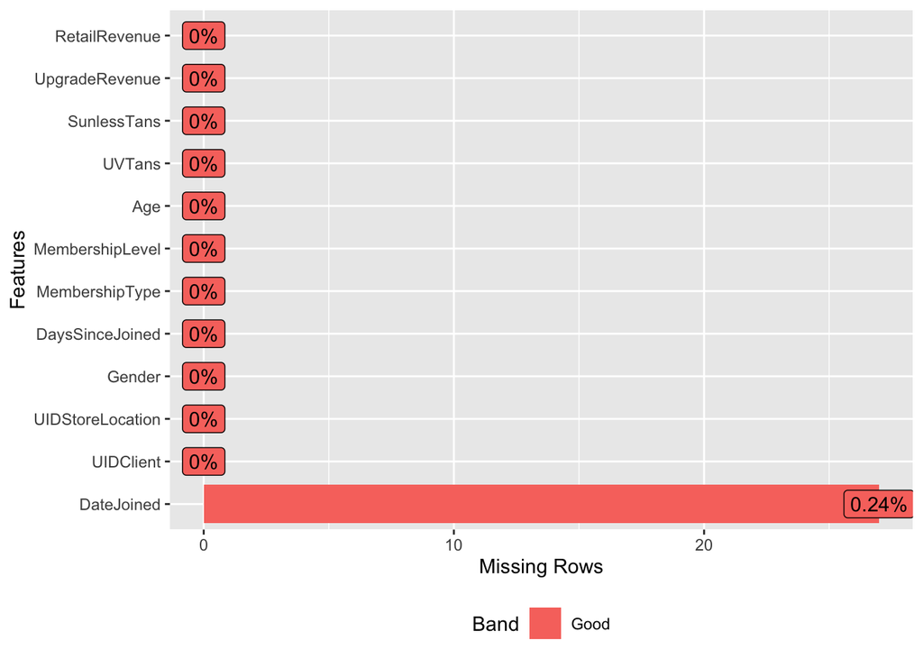

```r
plot_missing(BeachTan_original)
```

A very small percentage of DateJoined was missing. I will use na.omit to drop these rows with missing data since it is such a small percentage of the overall rows. I will do this after I check the distribution of the variables.

## 3.4 Checking the Distribution of Variables

I graphed the quantitative and qualitative variables to look for any unusual observations or extreme outliers because if any of these are present they will throw off the regression. There seems to be no extreme outliers or unusual observations except for in the DaysSinceJoined histogram. I will further analyze DaysSinceJoined to see why there are some extreme outliers.

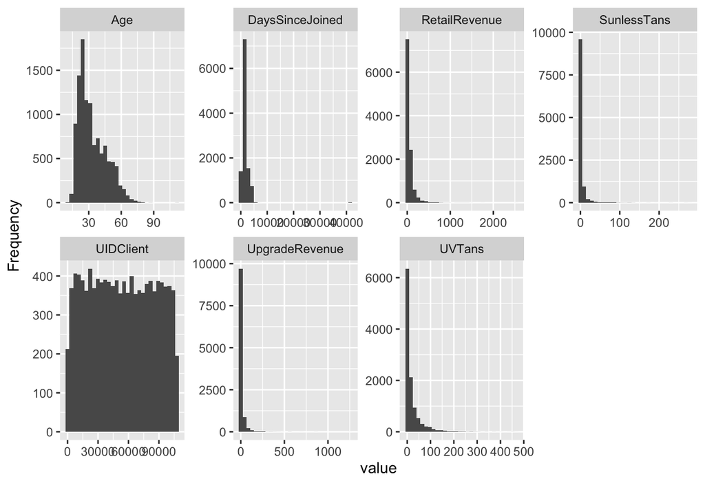

```r
plot_histogram(BeachTan_original)
```

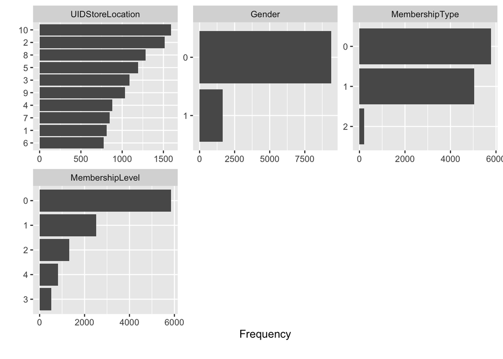

```r
plot_bar(BeachTan_original)
```

The variable DaysSinceJoined had some with values over 40,000, which means they joined over 100 years ago. This is because since DateJoined had some missing observations, DaysSinceJoined was way larger than it should have been for those observations. I simply removed those observations where DaysSinceJoined was greater than 40,000 because this does not make sense in terms of the problem.

```r
BeachTan_clean <- BeachTan_original %>% filter(DaysSinceJoined<40000)
```

I plotted DaysSinceJoined again to see if this fixed the issue.

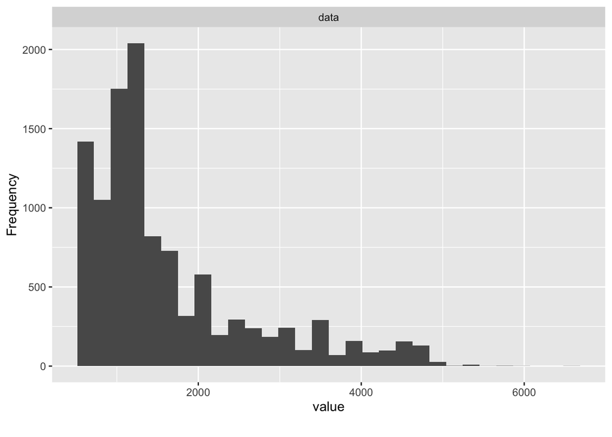

```r
plot_histogram(BeachTan_clean$DaysSinceJoined)
```

As you can see, there are no more extreme outliers, so this variable is now cleaned.

I now drop the small percentage of rows that were missing from DaysJoined.

```r
BeachTan_clean <- na.omit(BeachTan_original)
```

I now plotted the missing data again to make sure there is now no missing data.

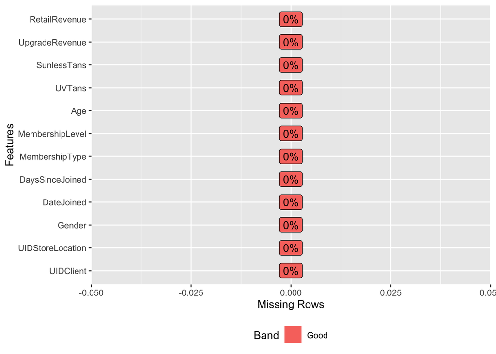

```r
plot_missing(BeachTan_clean)
```

## 3.5 Checking for Correlation Between Predictor Variables

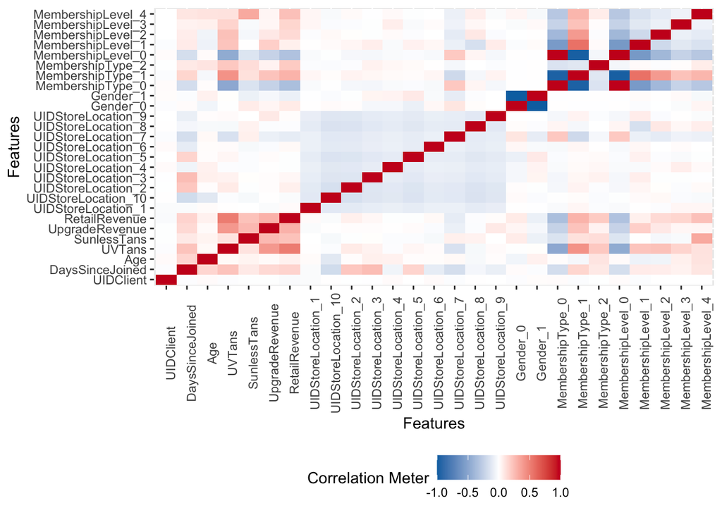

```r
plot_correlation(BeachTan_clean)
```

# 4 Final Analysis

## 4.1 Buidling a Multiple Linear Regression Model

I set a random seed so this regression can be produced again. Age was not found to be a significant predictor in the first regression I ran, so I excluded it from the following regression.

```r
options(scipen=999)
set.seed(13)
RetailRegression <- lm(RetailRevenue ~  Gender + MembershipType + MembershipLevel + UVTans + SunlessTans, data = BeachTan_clean)
summary(RetailRegression)
```

```
##
## Call:
## lm(formula = RetailRevenue ~ Gender + MembershipType + MembershipLevel +
##     UVTans + SunlessTans, data = BeachTan_clean)
##
## Residuals:
##     Min      1Q  Median      3Q     Max
## -556.31  -20.22  -10.14   11.36 2059.76
##
## Coefficients:
##                   Estimate Std. Error t value             Pr(>|t|)
## (Intercept)       16.08956    1.07356  14.987 < 0.0000000000000002 ***
## Gender1          -18.35929    2.07164  -8.862 < 0.0000000000000002 ***
## MembershipType1   15.84180   11.29643   1.402             0.160833
## MembershipType2   66.73434    9.11516   7.321    0.000000000000263 ***
## MembershipLevel1 -13.22611   11.26227  -1.174             0.240271
## MembershipLevel2   3.40276   11.40277   0.298             0.765392
## MembershipLevel3  32.67746   11.66312   2.802             0.005091 **
## MembershipLevel4  41.86599   11.40596   3.671             0.000243 ***
## UVTans             1.16484    0.02389  48.758 < 0.0000000000000002 ***
## SunlessTans        1.03223    0.06882  15.000 < 0.0000000000000002 ***
## ---
## Signif. codes:  0 '***' 0.001 '**' 0.01 '*' 0.05 '.' 0.1 ' ' 1
##
## Residual standard error: 77.32 on 10984 degrees of freedom
## Multiple R-squared:  0.3435, Adjusted R-squared:  0.343
## F-statistic: 638.7 on 9 and 10984 DF,  p-value: < 0.00000000000000022
```

## 4.2 Results from Multiple Linear Regression Model

It is important to note that the purpose of this model was to examine which predictor variables are significant predictors in predicting retail revenue. The RMSE is high and the multiple R-squared is low because at least one of the levels in MembershipType and MembershipLevel were found to not be significant. However, I kept these two variables in the model because at least one of their levels were found to be significant predictors.

*Gender Interpertation*

Males are far less likely to purchase retail than females are in the presence of the other predictors. I made a bar plot to better illustrate average retail revenue spending by gender.

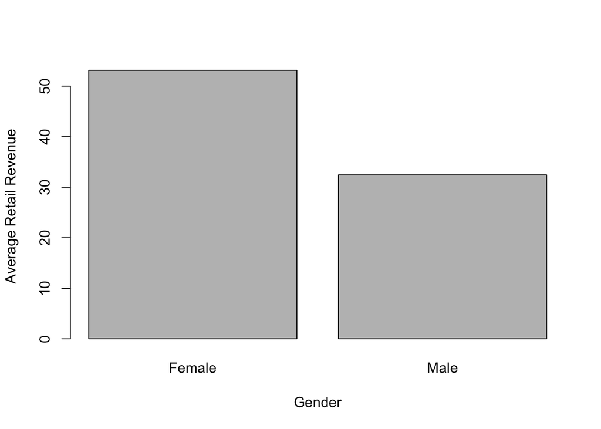

```r
barplot(aggregate(BeachTan_clean$RetailRevenue, by = list(BeachTan_clean$Gender),
                  mean, rm.na = T)[,2], xlab = "Gender", ylab = "Average Retail Revenue",
                  names.arg = c("Female", "Male"))
```

*MembershipType Interpertation*

Clients whose membership type is annual (MembershipType2) are most likely to purchase retail in the presence of the other predictor variables. Clients who are not members (MembershipType0) are least likely to purchase retail in the presence of the other predictors. I made a bar plot to better illustrate average retail revenue spending by membership type.

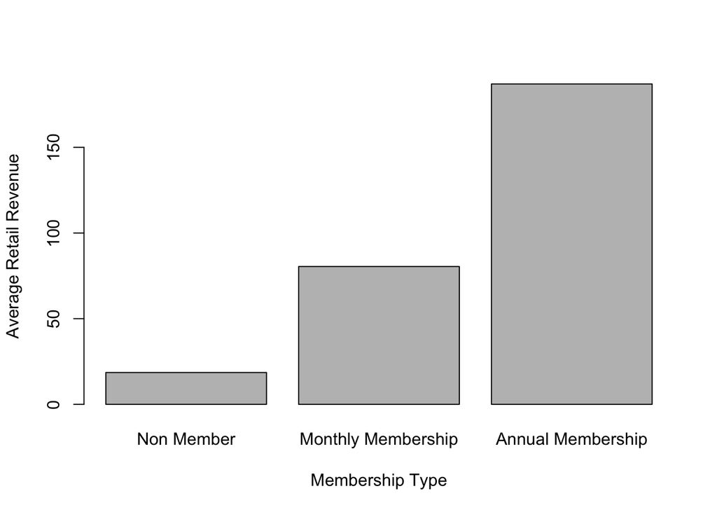

```r
barplot(aggregate(BeachTan_clean$RetailRevenue, by = list(BeachTan_clean$MembershipType),
                  mean, rm.na = T)[,2], xlab = "Membership Type", ylab = "Average Retail Revenue",
        names.arg = c("Non Member", "Monthly Membership", "Annual Membership"))
```

*MembershipLevel Interpertation*

Clients whose membership level are 3 and 4 are the most likely to purchase retail. Clients in Membership level 1 are the least likely to purchase retail in the presence of the other preditors. I wanted to see how membership level affects retail revenue without any other variables present so I made a bar plot to evalute average retail revenue spending based on membership levels. This bar plot illustrates that as a client’s membership level increases, so does retail revenue.

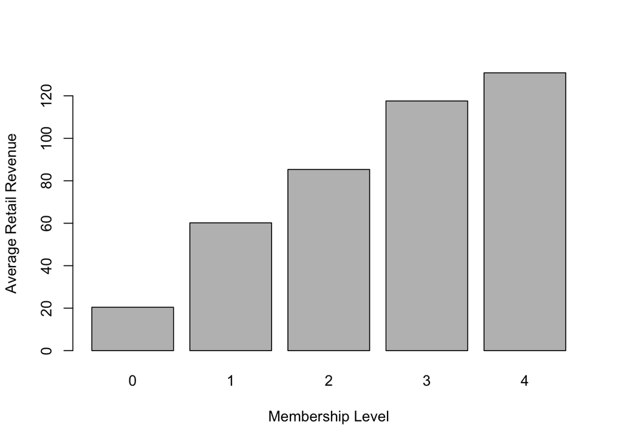

```r
barplot(aggregate(BeachTan_clean$RetailRevenue, by = list(BeachTan_clean$MembershipLevel),
                  mean, rm.na = T)[,2], xlab = "Membership Level", ylab = "Average Retail Revenue",
        names.arg = c("0", "1", "2", "3", "4"))
```

# 5 Conclusion

Overall, this regression model has allowed the marketing team to gain a better understanding of different client’s tanning habits and what type of clients are purchasing retail. This information will aid the marketing team in creating more customized promotions. These targeted promotions should lead to an increase in retail revenue.